# Aside

## Table of Contents

#### Education Skills Expertise Publications Preprints Acknowledgements Reviewerships Internal talks Invited talks Conference talks Posters Experience Teaching Packages Websites Databases Grants Awards Affiliations Data visualisation Extracurricular

*Updated Oct-20-2026*  
[*Made with autoCV*](https://github.com/bschilder/autoCV)

# Main

## Brian M Schilder, PhD

### Passionately pursuing transdisciplinary research to advance human health and knowledge.

Genomic AI Scientist

## Education

### Imperial College London / The Alan Turing Institute

PhD: Clinical Medical Research; Computational Genomics & Machine Learning

[London, UK](https://www.google.com/maps/place/London,+UK)

2024

**Thesis**: Multi-omic medicine: dissecting the cell type-specific and pleiotropic mechanisms underlying disease genomics at scale

### The George Washington University / Georgetown University

MPhil: Human Evolution; Comparative Neuroscience & Genomics

[Washington, DC, USA](https://www.google.com/maps/place/Washington,+DC,+USA)

2017

**Thesis**: The evolution of the hippocampus and adult neurogenesis: novel insights into the origins of human memory

- *Aim 1)*: Identify human-specific features of hippocampal subfield organization, adult neurogenesis, and their ecological correlates.
- *Aim 2)* Identify human-specific patterns of hippocampal subfield gene expression.
- *Aim 3)* Identify the genetic mechanisms mediating the evolution of human hippocampal neuroanatomy and gene expression.

### Brown University / Princeton University

ScB: Cognitive Neuroscience; Neurological Diseases & Disorders

[Providence, RI, USA](https://www.google.com/maps/place/Providence,+RI,+USA)

2011

## Core Skills

### Research

**17**+ years of deep expertise in genomics, AI, evolutionary biology and biomedicine. Strategically fuses concepts and methods across multiple domains.

N/A

N/A

### AI & Machine Learning

Proficient in developing and deploying AI/ML models (PyTorch, Keras, sklearn) to solve complex biological problems. Applied examples include:

N/A

- **Personalized VEP**: Adapted protein (ESM, AlphaFold), RNA (SpliceAI), and DNA (Flashzoi, phyloGPN, HyenaDNA) sequence models to generate personalized variant effect predictions for >100k clinical variants across >3,800 diverse human genomes. Demonstrated that sequence-based AI models capture biologically meaningful inter-individual variation, paving the way for personalized medicine.
- **TimelineTransformer**: Designed and trained an LLM-based time-series foundation model to predict patient health trajectories. Trained on 6.22M patient events.
- **Phenotype Severity Scoring**: Developed GPT-4-based framework to systematically score severity of 17k+ disease phenotypes to help reprioritization.
- **MedAgent**: A reproducible multi-agent system for summarizing and interpreting multimodal medical data, including EHR, imaging, and genomics.
- **ReporterSuite**: Created proprietary Python packages for advanced LLM-based topic modelling of the PubMed literature to provide business intelligence to the world’s largest digital health, biotech, and pharma companies (as a consultant with [120/80 Group](https://www.12080group.com/)).
- **echolocatoR**: Used functional impact predictions from DNA sequence models (DeepSEA, Basenji, IMPACT) to validate SNPs prioritised with Bayesian fine-mapping.

N/A

### Project Management

Efficient management strategies to define objectives, track progress and coordinate diverse teams.

N/A

- **Documentation**: Defines objectives and tracks progress with GitHub Projects. Includes useful documentation in Issues, inline code and shareable reports.
- **Version control**: Extensive and daily use of GitHub, containers (*Docker, Singularity, virtual machines*), environments (*conda*) and pipelines (*Nextflow*).
- **Team management**: Led numerous collaborative research projects and supervised researchers at various career stages.

N/A

### Soft Skills

Advances science through effective problem formulation, collaboration and communication.

N/A

- **Problem formulation**: Rapid hypothesis generation, project design, and creative problem solving.
- **Collaboration**: Diverse and global collaborative networking.
- **Communication**: Clear and concise distillation of complex results to a variety of audiences. Presented **25** conference posters.

N/A

## Expertise by Field

The total height of each column represents my overall expertise in a given domain. The color and height of each rectangle are scaled to my relative level of expertise within each subdomain.

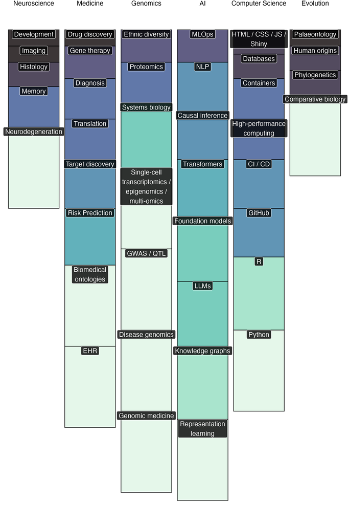

## Publications

### Cell type-specific contextualisation of the human phenome: towards the systematic treatment of all rare diseases

*Genome Medicine* (2026) 18(113); https://doi.org/10.1186/s13073-026-01692-0

N/A

2026

**BM Schilder**, KB Murphy, H Dash, Y Zhang, R Gordon-Smith, J Chapman, M Otani, NG Skene

### anndataR improves interoperability between R and Python in single-cell transcriptomics

*Bioinformatics* (2026) 42(6); https://doi.org/10.1093/bioinformatics/btag288

N/A

2026

L Deconinck, L Zappia, R Cannoodt, M Morgan, scverse core, I Virshup, C Sang-Aram, D Bredikhin, **BM Schilder**, R Seurinck, Y Saeys

### Using GPT-4 to annotate the severity of all phenotypic abnormalities within the human phenotype ontology

*Frontiers in Digital Health* (2026) 8(1794934); https://doi.org/10.3389/fdgth.2026.1794934

N/A

2026

KB Murphy, **BM Schilder**, NG Skene

### Gene expression dynamics of human and mouse craniofacial development at the single-cell level

*Nature Communications* (2026) 17(3714); https://doi.org/10.1038/s41467-026-70232-6

N/A

2026

N Khouri-Farah, EW Winchester, **BM Schilder**, K Robinson, SW Curtis, NM Skene, E Leslie-Clarkson, J Cotney

### monarchr: an R package for querying biomedical knowledge graphs

*Bioinformatics* (2025) 41(10); https://doi.org/10.1093/bioinformatics/btaf549

N/A

2025

ST O’Neil, **BM Schilder**, K Schaper, C Cox, D Korn, S Gehrke, CJ Mungall, MA Haendel

### Mondo: integrating disease terminology across communities

*Genetics* (2025) https://doi.org/10.1093/genetics/iyaf215

N/A

2025

NA Vasilevsky, … **BM Schilder**, …,PN Robinson, CJ Mungall, A Hamosh, MA Haendel

### Fine-mapping genomic loci refines bipolar disorder risk genes

*Nature Neuroscience* (2025) https://doi.org/10.1038/s41593-025-01998-z

N/A

2025

M Koromina, A Ravi, G Panagiotaropoulou, **BM Schilder**, … S Ripke, T Raj, JRI Coleman, N Mullins

### CUT&Tag recovers up to half of ENCODE ChIP-seq peaks

*Nature Communications* (2025) (16):2993; https://doi.org/10.1038/s41467-025-58137-2

N/A

2025

L Abbasova, P Urbanaviciute, D Hu, JN Ismail, **BM Schilder**, A Nott, NG Skene, SJ Marzi

### Chromatin Interaction and Histone Mark Signatures Associated With TBXT Expression in Metastatic Lung Cancer

*Genes Chromosomes Cancer,* (2025) (64):e70041; https://doi.org/10.1002/gcc.70041

N/A

2025

RM Yaa, **BM Schilder**, RD Acemel, FC Wardle

### rworkflows: automating reproducible practices for the R community

*Nature Communications* (2023) 15(149); https://doi.org/10.1038/s41467-023-44484-5

N/A

2023

**BM Schilder**, AE Murphy, NG Skene  
**News**  
- [Featured in *Nature Communications* Editors’ Highlights](https://www.nature.com/collections/idhhgedgig)

### Artificial intelligence for neurodegenerative experimental models

*Alzheimer’s & Dementia* (2023) http://doi.org/10.1002/alz.13479

N/A

2023

SJ Marzi, **BM Schilder**, A Nott, C Sala Frigerio, S Willaime-Morawek, M Bucholc, DP Hanger,C James, PA Lewis, I Lourida, W Noble, F Rodriguez-Algarra, JA Sharif, M Tsalenchuk, LM Winchester, U Yaman, Z Yao, DEMON Network, JM Ranson, DJ Llewellyn

### Artificial intelligence for dementia genetics and omics

*Alzheimer’s & Dementia* (2023) http://doi.org/10.1002/alz.13427

N/A

2023

C Bettencourt, NG Skene, S Bandres-Ciga, E Anderson, LM Winchester, IF Foote, J Schwartzentruber, JA Botia, M Nalls, A Singleton, **BM Schilder**, J Humphrey, SJ Marzi, CE Toomey, A Al Kleifat, EL Harshfield, V Garfield, C Sandor, S Keat, S Tamburin, C Sala Frigerio, I Lourida, DEMON Network, JM Ranson, DJ Llewellyn

### Artificial intelligence for dementia research methods optimization

*Alzheimer’s & Dementia* (2023) http://doi.org/10.1002/alz.13441

N/A

2023

M Bucholc, C James, A Al Khleifat, A Badhwar, N Clarke, A Dehsarvi, CR Madan, SJ Marzi, C Shand, **BM Schilder**, S Tamburin, HM Tantiangco, I Lourida, DJ Llewellyn, JM Ranson

### EpiCompare: R package for the comparison and quality control of epigenomic peak files

*Bioinformatics Advances* (2023) 13(1):vbad049; https://doi.org/10.1093/bioadv/vbad049

N/A

2023

S Choi, **BM Schilder**, L Abbasova, AE Murphy, NG Skene

### Dissecting the Shared Genetic Architecture of Suicide Attempt, Psychiatric Disorders, and Known Risk Factors

*Biological Psychiatry* (2022) 91(3):313-327; https://doi.org/10.1016/j.biopsych.2021.05.029

N/A

2022

N Mullins, J Kang, AI Campos,…**BM Schilder**, et al.

### Genetic analysis of the human microglial transcriptome across brain regions, aging and disease pathologies

*Nature Genetics* (2022) https://doi.org/10.1038/s41588-021-00976-y

N/A

2022

K de Paiva Lopes, G JL Snijders, J Humphrey, A Allan, M Sneeboer, E Navarro, **BM Schilder**…T Raj  
**News**  
- [Microglial transcriptomics meets genetics: new disease leads (Nature Reviews Neurology, 2022)](https://doi.org/10.1038/s41582-022-00633-w)  
- [Mighty MiGA: Microglial Genomic Atlas Zeros in on Causal AD Risk Variants (ALZFORUM, 2022)](https://www.alzforum.org/news/research-news/mighty-miga-microglial-genomic-atlas-zeros-causal-ad-risk-variants)  
- [Can a Human Microglial Atlas Guide Brain Disorder Research? (Mount Sinai Health System, 2022)](https://www.mountsinai.org/about/newsroom/2022/can-a-human-microglial-atlas-guide-brain-disorder-research)  
- [Polygenic Scores Paint Microglia as Culprits in Alzheimer’s (ALZFORUM, 2021)](https://www.alzforum.org/news/conference-coverage/polygenic-scores-paint-microglia-culprits-alzheimers)

### Multi-omic insights into Parkinson’s Disease: From genetic associations to functional mechanisms

*Neurobiology of Disease* (2021) 105580; https://doi.org/10.1016/j.nbd.2021.105580

N/A

2021

**BM Schilder**, E Navarro, T Raj

### Fine-Mapping of Parkinson’s Disease Susceptibility Loci Identifies Putative Causal Variants

*Human Molecular Genetics* (2021) ddab294; https://doi.org/10.1093/hmg/ddab294

N/A

2021

**BM Schilder**, T Raj

### echolocatoR: An Automated End-to-End Statistical and Functional Genomic Fine-Mapping Pipeline

*Bioinformatics* (2021) btab658; https://doi.org/10.1093/bioinformatics/btab658

N/A

2021

**BM Schilder**, J Humphrey, T Raj

### MungeSumstats: A Bioconductor Package for the Standardisation and Quality Control of Many GWAS Summary Statistics

*Bioinformatics* (2021) 37(23):4593-4596; https://doi.org/10.1093/bioinformatics/btab665

N/A

2021

A Murphy, **BM Schilder**, NG Skene

### Dysregulation of mitochondrial and proteo-lysosomal genes in Parkinson’s disease myeloid cells

*Nature Genetics* (2021) https://doi.org/10.1101/2020.07.20.212407

N/A

2021

E Navarro, E Udine, K de Paiva Lopes, M Parks, G Riboldi, **BM Schilder**…T Raj  
**News**  
- [Mount Sinai: Fighting Neurodegenerative Disorders (Mount Sinai Health System, 2019)](https://youtu.be/2TcBEiUtIy4)

### Phenome-wide and eQTL Associations of COVID-19 Genetic Risk Loci

*iScience* (2021) https://doi.org/10.1016/j.isci.2021.102550

N/A

2021

C Moon, **BM Schilder**, T Raj, K-l Huang

### Genome-Wide Association Study of over 40,000 Bipolar Disorder Cases Provides Novel Biological Insights

*Nature Genetics* (2021) 53:817-829; https://doi.org/10.1038/s41588-021-00857-4

N/A

2021

N Mullins, AJ Forstner, KS O’Connell, B Coombes, JRI Coleman…**BM Schilder**… et al.  
**News**  
- [Researchers identify 64 regions of the genome that increase risk for bipolar disorder (EurekAlert, 2021)](https://www.eurekalert.org/news-releases/577454)  
- [Largest Bipolar Disorder Genetics Study Doubles Genetic Risk Factors (Nordic Society of Human Genetics and Precision Medicine, 2021)](https://www.nshg-pm.org/largest-bipolar-genetics-study-doubles-risk)

### Tensor decomposition of stimulated monocyte and macrophage gene expression profiles identifies neurodegenerative disease-specific trans-eQTLs

*PLOS Genetics* (2020) 16(9):e1008549; https://doi.org/10.1371/journal.pgen.1008549

N/A

2020

S Ramdhani, E Navarro, E Udine, AG Efthymiou, **BM Schilder**, M Parks, A Goate, T Raj

### Evolutionary shifts dramatically reorganized the human hippocampal complex

*Journal of Comparative Neurology* (2019) 528(17):3143-3170; https://doi.org/10.1002/cne.24822

N/A

2019

**BM Schilder**, HM Petry, PR Hof

### FAIRshake: Toolkit to Evaluate the Findability, Accessibility, Interoperability, and Reusability of Research Digital Resources

*Cell Systems* (2019) 9; https://doi.org/10.1016/j.cels.2019.09.011

N/A

2019

D Clarke, L Wang, A Jones, M Wojciechowicz, D Torre, K Jagodnik, S Jenkins, P McQuilton, Z Flamholz, M Silverstein, **BM Schilder**…A Ma’ayan  
**News**  
- [Chosen as ‘Featured Frontmatter’ article in Cell Systems](https://doi.org/10.1016/j.cels.2019.09.011)

### Geneshot: search engine for ranking genes from arbitrary text queries

*Nucleic Acids Research* (2019) 47(W1):W571-W577; https://doi.org/10.1093/nar/gkz393

N/A

2019

A Lachmann, **BM Schilder**, ML Wojciechowicz, D Torre, MV Kuleshov, AB Keenan, A Ma’ayan  
**News**  
- [Geneshot: Piercing the Literature to Identify and Predict Relevant Genes (University of Pittsburgh Health Sciences Library System Update, 2019)](https://info.hsls.pitt.edu/updatereport/2019/july-2019/geneshot-piercing-the-literature-to-identify-and-predict-relevant-genes)  
- [The Future of AI at the Hasso Plattner Institute for Digital Health at Mount Sinai (Mount Sinai Health System, 2020)](https://youtu.be/tBKHWQsCANE?t=44)

### eXpression2Kinases (X2K) Web: linking expression signatures to upstream cell signaling networks

*Nucleic Acids Research* (2018) 46(W1):W171-W179; https://doi.org/10.1093/nar/gky458

N/A

2018

DJB Clarke, MV Kuleshov, **BM Schilder**, D Torre, ME Duffy, AB Keenan, A Lachmann, AS Feldmann, GW Gundersen, MC Silverstein, Z Wang  
**News**  
- [Mount Sinai Faculty Spotlight: Ma’ayan Lab (Mount Sinai Health System, 2018)](https://youtu.be/tB3BgSL4rXE)

### Defining elemental imitation mechanisms: A comparison of cognitive and motor-spatial imitation learning across object- and computer-based tasks

*Journal of Cognition and Development* (2015) 17(2):221-243; https://doi.org/10.1080/15248372.2015.1053483

N/A

2015

F Subiaul, L Zimmerman, E Renner, **BM Schilder**, R Barr

### Take the monkey and run

*Journal of Neuroscience Methods* (2015) 248:28-31; http://doi.org/10.1016/j.jneumeth.2015.03.023

N/A

2015

KA Phillips, MK Hambright, K Hewes, **BM Schilder**, CN Ross, SD Tardif  
**News**  
- [Monkeys on a Treadmill? A Conversation with Dr. Kimberley Phillips (Why Social Science?)](https://www.whysocialscience.com/blog/2016/9/6/monkeys-on-a-treadmill)

### Becoming a high-fidelity - super - imitator: what are the contributions of social and individual learning?

*Developmental Science* (2014) 18(6):1025-1035; http://doi.org/10.1111/desc.12276

N/A

2014

F Subiaul, EM Patterson, **BM Schilder**, E Renner, R Barr

### Working memory constraints on imitation and emulation

*Journal of Experimental Child Psychology* (2014) 128:190-200; http://doi.org/10.1016/j.jecp.2014.07.005

N/A

2014

F Subiaul, **BM Schilder**

## Preprints

### Genetic background shapes AI-predicted variant effects

*bioRxiv* (2026) https://doi.org/10.64898/2026.04.04.715328

N/A

2026

BM Schider, Z Liu, JJ Desmairis, D Laub, F Rahimi, P Sethi, LA Pereira, M Sun, JB Kinney, DM McCandlish, J Zhou, PK Koo

### orthogene: a Bioconductor package to easily map genes within and across hundreds of species

*bioRxiv* (2026) https://doi.org/10.64898/2026.01.17.700094

N/A

2026

**BM Schilder**, AE Murphy, NG Skene

### Integrative multi-omics analysis of glial signatures associated with accelerated cognitive decline in Alzheimer’s disease

*bioRxiv* (2024) https://doi.org/10.1101/2024.08.27.24312641

N/A

2024

E Schneegans, N Fancy, V Chau, TKD Cheung, E Adair, M Papageorgopoulou, **BM Schilder**, PM Matthews, JS Jackson

## Acknowledgements

### eQTL Catalogue: a compendium of uniformly processed human gene expression and splicing QTLs.

*Nature Genetics* (2021) 53:1290-1299; https://doi.org/10.1038/s41588-021-00924-w

N/A

2021

N Kerimov, JD Hayhurst, K Peikova et al.

### Functionally-informed fine-mapping and polygenic localization of complex trait heritability

*Nature Genetics* (2020) https://doi.org/10.1038/s41588-020-00735-5

N/A

2020

O Weissbrod…AL Price

### Wayfinding: The science and mystery of how humans navigate the world.

*St. Martin’s Press* (2019) ISBN-13: 978-1250096968; https://www.amazon.co.uk/Wayfinding-Science-Mystery-Humans-Navigate/dp/1250096960

N/A

2019

MR O’Connor

### EEG oscillations reveal neural correlates of evidence accumulation

*Frontiers in Decision Neuroscience* (2012) 6(106):13-Jan; https://doi.org/10.3389/fnins.2012.00106

N/A

2012

M van Vugt, P Simen, L Nystrom, P Holmes, J Cohen

### Trial-by-trial adaptation of decision making performance: a model-based EEG analysis

*Interdisciplinary Perspectives on Cognition, Education, and the Brain* (2011) 7; https://www.semanticscholar.org/paper/Trial-by-trial-adaptation-of-decision-making-a-EEG-Vugt-Simen/330371d08842ecd1bda332dd22351a7135b5cb1f

N/A

2011

M van Vugt, P Simen, J Cohen

## Reviewerships

### [Unpublished article]

*Associate Editor for Frontiers Genetics* (2025)

N/A

2025

### Mixture of Experts Enable Efficient and Effective Protein Understanding and Design

*Nature Methods* (2025)

N/A

2025

N Sun, S Zou, T Tao, S Mahbub, D Li, Y Zhuang, H Wang, X Cheng, L Song, EP Xing

### Compressing the collective knowledge of ESM into a single protein language model

*Nature Methods* (2025)

N/A

2025

T Dinh, S Jang, N Zaitlen, V Ntranos

### Large language models identify causal genes in complex trait GWAS

*Nature Communications* (2025)

N/A

2025

SS Shringarpure, W Wang, S Karagounis, X Wang, AC Reisetter, A Auton, AA Khan

### ENCORE: a practical implementation to improve reproducibility and transparency of computational research

*Nature Communications* (2025)

N/A

2025

AHC van Kampen, U Mahamune, A Jongejan, BDC van Schaik, D Balashova, D Lashgari, M Pras-Raves, EJM Wever, AD Dane, R García-Valiente, PD Moerland

### L2G: Repurposing Language Models for Genomics Tasks

*ISMB/ECCB* (2025) https://doi.org/10.1101/2024.12.09.627422

N/A

2025

W Cheng, J Shen, M Khodak, J Ma, A Talwalkar

### Enhancing regulatory variant prioritization via long-range DNA sequences and multi-task learning

*The American Journal of Human Genetics* (2025)

N/A

2025

Y Takahashi, QS Wang, T Hasegawa, H Namkoong, F Inoue, K Fukunaga, S Imoto, S Miyano, Y Okada, Japan COVID-19 Task Force

### Deciphering the tissue-specific functional effect of Alzheimer risk SNPs with deep genome annotation

*BioData Mining* (2024) https://doi.org/10.1186/s13040-024-00400-1

N/A

2024

PV Pugalenthi, B He, L Xie, K Nho, AJ Saykin, J Yan

### A genetic and transcriptomic assessment of the KTN1 gene in Parkinson’s disease risk

*Neurobiology of Aging* (2024) https://doi.org/10.1016/j.neurobiolaging.2023.11.001

N/A

2024

A Moore, PW Crea, M Makarious, S Bandres-Ciga, C Blauwendraat, M Diez-Fairen

### [Unpublished article]

*BMJ Open* (2024)

N/A

2024

### Multi-region brain transcriptomes uncover two subtypes of aging individuals with differences in Alzheimer risk and the impact of APOEε4

*Neuron* (2023) https://doi.org/10.1101/2023.01.25.524961

N/A

2023

AJ Lee, Y Ma, L Yu, RJ Dawe, C McCabe, K Arfanakis, R Mayeux, DA Bennett, HU Klein, PL De Jager

### Summary statistics-based association test for identifying the pleiotropic effects with set of genetic variants

*Bioinformatics* (2023) https://doi-org.iclibezp1.cc.ic.ac.uk/10.1093/bioinformatics/btad182

N/A

2023

D Bu, X Wang, Q Li

### Most pathways can be related to the pathogenesis of Alzheimer’s Disease

*Alzheimer’s Research & Therapy* (2021) https://doi.org/10.3389/fnagi.2022.846902

N/A

2021

SL Morgan, P Naderi, K Koler, Y Pita-Juarez, D Prokopenko, IS Vlachos, RE Tanzi, L Bertram, WA Hide

### CLIP: accurate prediction of disordered linear interacting peptides from protein sequences using co-evolutionary information

*Bioinformatics* (2021) https://doi.org/10.1093/bib/bbac502

N/A

2021

Z Peng, Z Li, Q Meng, B Zhao, L Kurgan

### Single-cell transcriptomics and in situ morphological analyses reveal microglia heterogeneity across the nigrostriatal pathway

*Neurobiology of Disease* (2020) https://doi.org/10.3389/fimmu.2021.639613

N/A

2020

O Uriarte Huarte, D Kyriakis, T Heurtaux, Y Pires-Afonso, K Grzyb, R Halder, M Buttini, A Skupin, M Mittelbronn, A Michelucci

### Deconstructing cerebellar development cell by cell

*PLOS Genetics* (2019) https://doi.org/10.1371/journal.pgen.1008630

N/A

2019

MJ van Essen, S Nayler, EBE Becker, J Jacob

### Partitioning the genetic architecture of amyotrophic lateral sclerosis

*Nature Neuroscience* (2019) https://doi.org/10.1101/505693

N/A

2019

IJ Broce,… RS Desikan

## Internal Talks

### Drug (re)discovery in the age of genomics: multi-omic strategies for identifying disease treatments

Seminar  
Drug Discovery and Trials Optimisation Working Group  
Deep Dementia Phenotyping Network (DEMON)

N/A

2022

### We’ve tagged a lot of cells, and sorted them in wells, some of the reads were double, So we looked into the trouble

Seminar  
UK Dementia Research Institute  
Imperial College London

N/A

2021

### Beyond GWAS: getting more out of genomic data in the age of machine learning

Methods Optimisation Working Group  
Deep Dementia Phenotyping Network (DEMON)

N/A

2021

### Interspecies translation of single-cell transcriptomic signatures

Seminar  
Experimental Models Working Group  
Deep Dementia Phenotyping Network (DEMON)

N/A

2021

### Automated consensus fine-mapping of neurological disorder genomics

Seminar  
UK Dementia Research Institute (UK DRI)

N/A

2020

## Invited Talks

### Navigating the Phenomic Landscape: Systematic characterisation of the latent genomic space underlying all traits and diseases

Mondo Outreach Call  
Monarch Initiative

N/A

2024

### Harnessing AI to annotate the severity of all phenotypic abnormalities within the Human Phenotype Ontology

Turing Omics Meeting  
Omics Data Generation & Analysis Group  
The Alan Turing Institute

N/A

2024

### Multi-omics medicine: investigating shared genetic risk factors to better understand neurodegenerative disease

Turing Omics Meeting  
Omics Data Generation & Analysis Group  
The Alan Turing Institute

N/A

2023

### Decomposing the phenome: learning the latent genomic structure underlying thousands of diseases and traits

Neuroepidemiology of Aging Webinar  
RUSH Alzheimer’s Disease Center (RADC)  
RUSH University

N/A

2022

### Drug (re)discovery in the age of genomics: multi-omic strategies for identifying disease treatments

Department Seminar  
3D (Drug, Disease, Delivery) Center / Department of Pharmaceutical Sciences  
University of South Dakota

N/A

2022

### Statistical and functional genetic fine-mapping across multiple disease

Seminar  
Alzheimer’s Disease Sequencing Project  
Columbia University / Icahn School of Medicine at Mount Sinai

N/A

2020

### Statistical and functional genetic fine-mapping across multiple disease

Laboratory of Neurogenetics Friday Workshop  
National Institute on Aging  
National Institutes of Health

N/A

2020

## Conference Talks

### Evaluating the sensitivity of genomic foundation models to interindividual variation using biobank-scale personalized genomes

AI x Bio  
Wellcome Genome Campus

N/A

2025

### rworkflows: taming the Wild West of R packages

EuroBioc2023  
Bioconductor

N/A

2023

[45-minute workshop.](https://eurobioc2023.bioconductor.org/abstracts/paper2/)

### rworkflows: taming the Wild West of R packages

BioC2023  
Bioconductor

N/A

2023

[10-minute talk within the Infrastructure Track.](https://www.youtube.com/watch?v=qdwbJOpVsvU&t=698s)

### Navigating the rare diseases landscape: A comprehensive approach to identify gene therapy targets based on cell type-phenotype associations

Intelligent Systems For Molecular Biology / European Conference on Computational Biology (ISMB/ECCB)  
International Society for Computational Biology (ISMB)

N/A

2023

[20-minute talk within the Bio-Ontologies COSI Track.](https://youtu.be/ceDPol88fC8)

### Systematic quantification of animal model viability across human diseases

Informatics-Synapse Joint Early Career Researcher Meeting  
UK Dementia Research Institute (UK DRI)

N/A

2022

### Automated genetic fine-mapping of neurological disorders

London Genetics Network  
The Genetics Society

N/A

2020

[6-minute talk](https://youtu.be/ScGsZ5jJnTo)

### Parkinson’s disease derived monocytes show alteration in the phago-lysosomal pathway

American Society of Human Genetics (ASHG) Annual Meeting  
American Society of Human Genetics (ASHG)

N/A

2019

Co-contributor

### Comparative neuroanatomy of navigational maps in primates

JB Johnston Club for Evolutionary Neuroscience  
Society for Neuroscience (SfN)

N/A

2017

Co-contributor

### The evolution of human hippocampal gene expression

JB Johnston Club for Evolutionary Neuroscience  
Society for Neuroscience (SfN)

N/A

2016

### The neurobiological effects of exercise on marmoset models of Multiple Sclerosis

Marmoset Social  
Society for Neuroscience (SfN)

N/A

2015

### The neurobiological effects of exercise on marmoset models of Multiple Sclerosis

JB Johnston Club for Evolutionary Neuroscience  
Society for Neuroscience (SfN)

N/A

2015

## Conference Posters

### Navigating the Phenomic Landscape: systematic characterisation of the latent genomic space underlying all traits and diseases

*Target to Patient* (2024) https://www.ebi.ac.uk/industry/targettopatient/

N/A

2024

BM Schilder, NG Skene

### CUT&Tag recovers up to half of ENCODE ChIP-seq peaks

*Connectome (UK Dementia Research Institute)* (2023) https://ukdri.ac.uk/

N/A

2023

J Ismail, D Hu, L Abbasova, BM Schilder, A Nott, NG Skene, SJ Marzi

### Navigating the rare diseases landscape: A comprehensive approach to identify gene therapy targets based on cell type-phenotype associations

*Intelligent Systems For Molecular Biology / European Conference on Computational Biology (ISMB/ECCB)* (2023) https://www.iscb.org/ismbeccb2023

N/A

2023

BM Schilder, KB Murphy, R Gordon-Smith, J Chapman, M Otani, NG Skene

### Identification of cell type-specific gene targets underlying thousands of rare diseases and clinical phenotypes

*Genomics of Rare Diseases* (2023) https://coursesandconferences.wellcomeconnectingscience.org/event/genomics-of-rare-disease-20230424/

N/A

2023

BM Schilder, KB Murphy, R Gordon-Smith, J Chapman, M Otani, NG Skene

### Statistical and Functional Fine-Mapping as a Powerful Tool to Unravel the Biological Etiology of Bipolar Disorder

*Biological Psychiatry* (2023) 93(9):S18; https://doi.org/10.1016/j.biopsych.2023.02.063

N/A

2023

M Koromina, A Ravi, BM Schilder, B Muller, J Coleman, T Raj

### Systematic quantification of animal model viability across human disease

*UK Dementia Research Institute Scientific Advisory Board* (2023)

N/A

2023

BM Schilder, NG Skene

### Systematic quantification of animal model viability across human disease

*Rising Scientist Day at Imperial College London* (2022)

N/A

2022

BM Schilder, NG Skene

### A compehensive statistical and functional fine-mapping pipeline applied to Bipolar Disorder GWAS risk loci

*European Neuropsychopharmacology* (2022) 63:e14; http://dx.doi.org/10.1016/j.euroneuro.2022.07.037

N/A

2022

M Koromina, A Ravi, BM Schilder, B Muller, J Coleman, T Raj, N Mullins

### Genetic Effects on Human Microglia Transcriptome in Neuropsychiatric Diseases

*Biological Psychiatry* (2021) 89(9):S84-S85; https://doi.org/10.1016/j.biopsych.2021.02.225

N/A

2021

G Snijders, K de Paiva Lopes, J Humphrey, S Allan, M Sneeboer, R Navarro, BM Schilder, R Vialle, M Parks, R Missall, W van Zuiden, F Gigase, R Kubler, AB van Berlekom, C Bottcher, J Priller, R Kahn, L de Witte, T Raj

### Cell-type-specific reconstruction of primate evolution from genomic positive selection

*Rising Scientist Day at Imperial College London* (2020)

N/A

2020

K Murphy, BM Schilder, NG Skene

### Automated genetic and functional fine-mapping of Parkinson’s Disease Loci

*American Society of Human Genetics* (2019)

N/A

2019

BM Schilder, T Raj

### Parkinson’s disease derived monocytes show alteration in the phago-lysosomal pathway

*American Society of Human Genetics* (2019)

N/A

2019

E Udine, E Navarro, …BM Schilder, …T Raj

### Learning X2K: Parameter Optimization via Genetic Algorithms to Calibrate the Expression2Kinases Pipeline

*Illuminating the Druggable Genome* (2018)

N/A

2018

BM Schilder, A Lachmann, M Kuleshov, A Ma’ayan

### Learning X2K: Parameter Optimization via Genetic Algorithms to Calibrate the Expression2Kinases Pipeline

*Big Data 2 Knowledge - Library of Integrated Network-Based Cellular Signatures (LINCS)* (2018)

N/A

2018

BM Schilder, A Lachmann, M Kuleshov, A Ma’ayan

### The evolution of the human hippocampus and neuroplasticity

*Association for American Physical Anthropologists* (2017) https://www.abstractsonline.com/pp8/index.html#!/4071/presentation/4471

N/A

2017

BM Schilder, BJ Bradley, CC Sherwood

### The molecular evolution of plasticity and the human hippocampus

*Society for Neuroscience* (2016) https://www.abstractsonline.com/pp8/index.html#!/4071/presentation/4471

N/A

2016

BM Schilder, BJ Bradley, CC Sherwood

### Effects of exercise on disease progression and cognition in the marmoset EAE model

*JB Johnston Club for Evolutionary Neuroscience* (2015)

N/A

2015

KA Phillips, MK Hambright, K Hewes, BM Schilder, B Jagessar, B t’Hart, SD Tardif

### The effects of climatic trends, variability, and rates of change on mammalian brain evolution

*Association for American Physical Anthropologists* (2015)

N/A

2015

BM Schilder, WA Barr, R Bobe, CC Sherwood

### Individual, Observational, and Imitation Learning in Orangutans and Children

*Association for American Physical Anthropologists* (2015)

N/A

2015

E Renner, BM Schilder, F Subiaul

### The helper hinderer task revisited: an infant eye tracking study

*The George Washington University Research Day* (2014)

N/A

2014

A Gokhale, BM Schilder, F Subiaul

### Dendritic morphology of pyramidal neurons across the visual stream: A direct comparison of chimpanzees and humans

*Society for Neuroscience* (2013)

N/A

2013

BM Schilder, O Adeyo

### The striatum in the evolution of learned vocalizations: Understanding the neurobiological precursors to human speech using a chimpanzee model

*Society for Neuroscience* (2013)

N/A

2013

S Bianchi, T Duka, G Muntane, BM Schilder, CD Stimpson, WD Hopkins

### Imitation & emulation in a novel box task

*Association for Psychological Science* (2013)

N/A

2013

L Zimmerman, N Brito, C Mendelson, R Barr, E Renner, BM Schilder, F Subiaul

### A study of imitation and working memory in 2- to 4- year-olds

*Association for Psychological Science* (2013)

N/A

2013

R Barr, F Subiaul, L Zimmerman, L Renner, BM Schilder, C Mendelson, L Golojuch

### The impact of wealth on sharing preferences in children

*Child Development Society* (2013)

N/A

2013

J Miller, BM Schilder, L Peizer, F Subiaul

## Research Experience

### AI Scientist

Standard Model Biomedicine

[Philadelphia, PA, USA](https://www.google.com/maps/place/Philadelphia,+PA,+USA)

- - 2026

- Building multimodal world models of patient health. Specifically, I lead the design and development of AI models that transform whole-genomes into personalized clinical predictions.

### Postdoctoral Research Scientist

Cold Spring Harbor Laboratory (Simons Center for Quantitative Biology)

[Cold Spring Harbor, NY, USA](https://www.google.com/maps/place/Cold+Spring+Harbor,+NY,+USA)

- - 2024

- Advancing deep learning applications in genomics and biomedicine in the laboratory of Dr. Peter Koo.
- Developing a genomic foundation model to map complex genome-phenome relationships and make highly accurate, personalized disease risk predictions.

### Lead Data Scientist

120/80 Group

[New York, NY, USA](https://www.google.com/maps/place/New+York,+NY,+USA)

- - 2019

- Offers data-driven consultation services to a wide portfolio of high-profile digital healthcare, pharmaceutical and biotech companies.
- Developed a suite of proprietary softwares to extract customised business intelligence from the published literature to generate customised and interpretable reports to clients.
- Provides clients guidance on strategic AI implementation, data analysis, publication and transparency.

### Bioinformatician II

Icahn School of Medicine at Mount Sinai (Department of Neuroscience / Department of Neurology / Department of Genetics & Genomics / Ronald M. Loeb Center for Alzheimer’s Disease)

[New York, NY, USA](https://www.google.com/maps/place/New+York,+NY,+USA)

2020 - 2018

- Developed machine learning systems to integrate large-scale multi-omics datasets (e.g. whole-genome sequencing, bulk and single-cell RNA-seq, epigenomics, clinical data) to uncover the molecular mechanisms underlying neurodegenerative diseases (e.g. Alzheimer’s, Parkinson’s, ALS).
- Computationally identified specific disease-causal variants, pathways and cell-types for subsequent functional wet lab validation (e.g. CRISPR-cas9 editing in patient-derived cell cultures, iPSCs and cerebral organoids).

### Bioinformatician II

Icahn School of Medicine at Mount Sinai (Department of Pharmacological Sciences)

[New York, NY, USA](https://www.google.com/maps/place/New+York,+NY,+USA)

2018 - 2017

- Conducted computational systems biology research. Integrated and analyzed large-scale genomic and biomedical data (e.g. Python, R, JavaScript).
- Developed evolutionary algorithm to optimize gene network kinase regulator prediction (eXpression2Kinases).
- Developed and deployed computational tools, software, databases and web applications for basic and clinical research, resulting in 3 peer-reviewed publications.

### Participant

Technische Universität Dresden / eMed (Summer School in Systems Medicine)

[Frauenchiemsee, Germany](https://www.google.com/maps/place/Frauenchiemsee,+Germany)

2017

- Attended lectures and extended skills in extraction and analysis of big data from biomedical and neurogenomic resources.
- Developed, performed and wrote manuscript for collaborative bioinformatics research project in less than one week.

### Participant

Icahn School of Medicine at Mount Sinai (Scientific Computing & Data Science)

[New York, NY, USA](https://www.google.com/maps/place/New+York,+NY,+USA)

2016

- Intensive summer school in high-performance computing, coding, genome database utilization and bioinformatics methods including transcriptomics and genetic association testing.

### Collaborator

Trinity University / Southwestern National Primate Research Center (Department of Neuroscience)

[San Antonio, TX, USA](https://www.google.com/maps/place/San+Antonio,+TX,+USA)

2017 - 2014

- Investigated the neurobiological mechanisms underlying the ameliorating effects of exercise on relapse-remitting Multiple Sclerosis.

### Teaching Assistant / Project Leader

The George Washington University / Rutgers University (Department of Anthropology)

[Ileret, Kenya](https://www.google.com/maps/place/Ileret,+Kenya)

2014

- Served as Teaching Assistant while excavating Lower Paleolithic hominin sites (Homo, Paranthropus).
- As Project Leader, investigated the running biomechanics of local Daasanach tribespeople while mentoring undergraduate students.

### Research Assistant

The George Washington University (Department of Anthropology)

[Washington, DC, USA](https://www.google.com/maps/place/Washington,+DC,+USA)

2013 - 2011

- Performed dissection, histology, microscopy and quantitative stereology in post-mortem primate brain tissues.
- Trained junior and senior personnel on lab protocols.

### Senior Lab Manager

The George Washington University (Department of Speech, Language & Hearing Sciences)

[Washington, DC, USA](https://www.google.com/maps/place/Washington,+DC,+USA)

2013 - 2011

- Organized and trained dozens of undergraduates to conduct weekly cognitive development research; designed and/or directly contributed to over 15 research projects in two years.

### Volunteer Researcher

University of Winnipeg / University of Belgrade (Department of Anthropology / Department of Archaeology)

[Sićevo, Serbia](https://www.google.com/maps/place/Sićevo,+Serbia)

2012

- Excavated Paleolithic fossils and tools (H. heidelbergensis, H. neanderthalensis) at Mala Balanica, Velika Balanica, and Pešturina sites.

### Volunteer Researcher

Universidad de Murcia (Department of Zoology & Physical Anthropology)

[Murcia, Spain](https://www.google.com/maps/place/Murcia,+Spain)

2011

- Excavated Paleolithic fossils and tools from Cueva Negra (H. heidelbergensis) and Sima de las Palomas (H. neanderthalensis) with an international research team.

### Volunteer Research Intern

American Museum of Natural History (Division of Anthropology)

[New York, NY, USA](https://www.google.com/maps/place/New+York,+NY,+USA)

2011

- Contributed to paleoanthropological research on primate fossils using 3D morphometry imaging equipment including Minolta, Microscribe and CT.

### Paid Research Intern

Princeton University (Princeton Neuroscience Institute)

[Princeton, NJ, USA](https://www.google.com/maps/place/Princeton,+NJ,+USA)

2010

- Investigated the neural basis of decision-making in humans.
- Recruited participants, recorded EEG and analyzed data in MATLAB.

### Student Researcher

Brown University (Department of Cognitive, Linguistic & Psychological Sciences)

[Providence, RI, USA](https://www.google.com/maps/place/Providence,+RI,+USA)

2010 - 2009

- Experimental Analysis of Animal Behavior & Cognition: Conducted various operant conditioning experiments on rats. Gained experience in animal behavioral training, data collection, and data analysis in MATLAB.
- Laboratory in Genes and Behavior: Tested transgenic mice with modified N-type voltage-gated calcium channel subunits in a battery of cognitive and sensorimotor tasks. Results were published.

## Teaching / Mentoring Experience

### Research Mentor

Imperial College London (Department of Brain Sciences / Department of Life Sciences)

[London, UK](https://www.google.com/maps/place/London,+UK)

- - 2020

- Mentored students and affiliated projects:
- Kitty Murphy (PhD): ‘Evolutionary pressures on cell types: leveraging species differences to gain insight into neurodegenerative disease risk’
- Sheen Lei (BSc): ‘Benchmarking cell-type-specific enrichment of genome-wide disease signatures’
- Ted Reese (MSc): ‘Computational cell-type annotation of single-cell epigenomics data’
- Xindong Sun (MSc): ‘Benchmark of Targeted insertion of promoters sequencing (TIP-seq) on histone modification H3K27ac and H3K27me3 in K562 cell line’
- Shuhan Shen (MSc): ‘Evaluation and optimisation of methods for identifying the cell types underlying genetic disease signatures’
- Lusheng Li (MSc): ‘Genetic identification of cell types underlying mammalian phenotypes’
- Sera Choi (BSc): ‘EpiCompare: R package for QC and benchmarking epigenetic datasets’
- Emilie Cottard (MSc) & Will Lunt (BSc): ‘A meta-analysis of selective cell-type vulnerability in Parkinson’s Disease neuropathology’
- Jai Chapman (BSc): ‘Expression Weighted Cell Type Enrichment as a Tool for Identifying Cell Types Underlying Rare Disease Phenotypes’
- Bobby Gordon-Smith (MSc): ‘Identification of cell types involved in rare disease-associated human phenotypes’
- Leyla Abbasova (MSc): ‘Analysis and optimisation of CUT&Tag for epigenomic profiling of the brain’
- Barney Hill (BSc): ‘Identification of cell-types associated with latent factors inferred from phenome-wide GWAS summary statistics’

### Research Mentor

Icahn School of Medicine at Mount Sinai (Department of Neuroscience / Department of Neurology / Department of Genetics & Genomics / Ronald M. Loeb Center for Alzheimer’s Disease)

[New York, NY, USA](https://www.google.com/maps/place/New+York,+NY,+USA)

2020 - 2019

- Mentored MS, MD, and PhD students in projects focused on computational exploration of phenotype clustering and genomic regulation of neurodegenerative diseases.

### Research Co-mentor

Icahn School of Medicine at Mount Sinai (Department of Pharmacological Sciences)

[New York, NY, USA](https://www.google.com/maps/place/New+York,+NY,+USA)

2018

- Mentored students and affiliated projects:
- Vivian Utti (BSc): ‘ChEA3: Transcription Factor Enrichment Analysis’ as part of the Summer Research Training Program in Biomedical Big Data Science.
- Mary Duffy (PhD): ‘Predicting upstream kinase regulators from interaction network databases’
- Zach Flamholz (BSc): ‘modEnrichr: a suite of gene set enrichment analysis tools for model organisms’

### Guest Lecturer

Icahn School of Medicine at Mount Sinai (Department of Pharmacological Sciences)

[New York, NY, USA](https://www.google.com/maps/place/New+York,+NY,+USA)

2018

- Lectured on data visualization in Python and Jupyter notebooks in the PhD/MD course ‘Programming for Big Data Biomedicine’.

### Research Mentor

The George Washington University (Department of Anthropology)

[Washington, DC, USA](https://www.google.com/maps/place/Washington,+DC,+USA)

2017 - 2016

- Mentored students and affiliated projects:
- Jamie Kleiner (BSc): ‘Animal model simulating MS and exercise’s impact on adult hippocampal neurogenesis’

### Teaching Assistant

The George Washington University (Department of Anthropology)

[Washington, DC, USA](https://www.google.com/maps/place/Washington,+DC,+USA)

2015

- Course: ‘Human Brain Evolution’
- Guest lectured, graded all assignments and exams, and provided additional educational support during office hours.

### Teaching Assistant

The George Washington University (Department of Psychology)

[Washington, DC, USA](https://www.google.com/maps/place/Washington,+DC,+USA)

2014

- Course: ‘Biological Psychology’
- Led undergraduates in article discussions, graded all assignments and exams, and provided additional educational support during office hours.

### Teaching Assistant

The George Washington University (Department of Anthropology)

[Washington, DC, USA](https://www.google.com/maps/place/Washington,+DC,+USA)

2014 - 2013

- Course: ‘Biological Anthropology’
- Led undergraduate students in two, 2-hour lab sessions per week, graded lab assignments and exams, and provided additional educational support during office hours.

### Research Mentor

The George Washington University (Department of Psychology)

[Washington, DC, USA](https://www.google.com/maps/place/Washington,+DC,+USA)

2013 - 2012

- Mentored students and affiliated projects:
- Anushka Gokhale (BSc): ‘Infants’ Social Assessment of Characters Through Eye Gaze’

### Lab Protocol Trainer

The George Washington University (Department of Anthropology)

[Washington, DC, USA](https://www.google.com/maps/place/Washington,+DC,+USA)

2013 - 2011

- Trained undergraduate, graduate, and post-doctoral researchers in Social Cognition Lab and Lab for Evolutionary Neuroscience in a variety of methodological research protocols.

## Software Packages

### CuEvo

GPU-accelerated analyses for intra- and inter-species evolution.

N/A

1.

### CuGen

A GPU-accelerated framework for large-scale genomics.  
https://github.com/yuj1r0/cugen

N/A

2.

### sparseNMF

GPU-accelerated sparse non-negative matrix factorization with PyTorch  
https://github.com/bschilder/sparseNMF

N/A

3.

### SynthLab

Python toolkit for generating synthetic patient data types: EHR, genomics, imaging, and more.  
https://github.com/bschilder/synthlab

N/A

4.

### MSTExplorer

Multi-Scale Targets Explorer: Systematically identify, prioritise and visualise cell-type-specific gene therapy targets across the phenome.  
https://github.com/neurogenomics/MSTExplorer  
https://doi.org/10.1101/2023.02.13.23285820

N/A

5.

### HPOExplorer

Import, annotate and visualise the 18k+ hierarchically structured clinical phenotypes across the Human Phenotype Ontology.  
https://github.com/neurogenomics/HPOExplorer  
https://doi.org/10.1101/2023.02.13.23285820

N/A

6.

### KGExplorer

Query, construct, and analyse large-scale biomedical knowledge graphs and ontologies.  
https://github.com/neurogenomics/KGExplorer

N/A

7.

### autoCV

Automatically generate and style your CV from tables.  
https://github.com/bschilder/autoCV

N/A

8.

### anndataR

Bring the power and flexibility of AnnData to the R ecosystem, allowing you to effortlessly manipulate and analyze your single-cell data.  
https://github.com/scverse/anndataR

N/A

9.

### gptPhD

Query Large Language Models for the purposes of systematically extracting biomedical knowledge.  
https://github.com/neurogenomics/gptPhD

N/A

10.

### ThreeWayTest

Summary statistics-based association test for identifying the pleiotropic effects with set of genetic variants.  
https://github.com/bschilder/ThreeWayTest

N/A

11.

### SCAVENGE

Variant to function mapping at single-cell resolution through network propagation.  
https://github.com/sankaranlab/SCAVENGE  
https://doi.org/10.1038/s41587-022-01341-y

N/A

12.

### rworkflows

Continuous integration for R packages. Automates testing, documentation website building, and containerised deployment.  
https://github.com/neurogenomics/rworkflows  
https://doi.org/10.21203/rs.3.rs-2399015/v1

N/A

13.

### TIPseeker

R package for post-processing [single-cell] TIP-seq data.  
https://github.com/neurogenomics/TIPseeker

N/A

14.

### PeakyFinders

R package for mining, calling, and importing epigenomic peaks.  
https://github.com/neurogenomics/PeakyFinders

N/A

15.

### graphiti

Extract colour palettes from graffiti artworks.  
https://github.com/bschilder/graphiti

N/A

16.

### SkillNet

Creates user-specific contribution networks from GitHub Organization repositories.  
https://github.com/neurogenomics/SkillNet

N/A

17.

### phenoRx

Make cell type-specific predictions for patients based on clinical phenotypes and/or risk genes.  
https://github.com/neurogenomics/phenoRx

N/A

18.

### phenomix

R package for the exploration and analysis of many genotype-phenotype datasets at once.  
https://github.com/neurogenomics/phenomix

N/A

19.

### MAGMA.Celltyping

Identify cell types underlying the associations found in GWAS summary statistics.  
https://github.com/neurogenomics/MAGMA_Celltyping

N/A

20.

### EWCE

Expression Weighted Celltype Enrichment.  
https://github.com/NathanSkene/EWCE

N/A

21.

### EpiCompare

R package for QC and benchmarking epigenetic datasets.  
https://github.com/neurogenomics/EpiCompare  
https://doi.org/10.1101/2022.07.22.501149

N/A

22.

### orthogene

Interspecies gene mapping.  
https://github.com/neurogenomics/orthogene

N/A

23.

### MungeSumstats

Standardise the format of summary statistics from GWAS.  
https://github.com/neurogenomics/MungeSumstats  
https://doi.org/10.1093/bioinformatics/btab665

N/A

24.

### scNLP

Tools for applying natural language processing (NLP) techniques to single-cell (sc) omics data.  
https://github.com/neurogenomics/scNLP

N/A

25.

### scKirby

Automated ingestion and conversion of various single-cell data formats.  
https://github.com/neurogenomics/scKirby

N/A

26.

### geneshotR

R package for querying and processing results from [Geneshot](https://maayanlab.cloud/geneshot/).  
https://github.com/bschilder/geneshotR

N/A

27.

### templateR

Self-updating template for developing R packages.  
https://github.com/neurogenomics/templateR  
https://doi.org/10.21203/rs.3.rs-2399015/v1

N/A

28.

### echoverseTemplate

Self-updating template for creating echoverse R packages.  
https://github.com/RajLabMSSM/echoverseTemplate/  
https://doi.org/10.1093/bioinformatics/btab658

N/A

29.

### echolocatoR

R package for end-to-end statistical and functional fine-mapping with extensive dataset access.  
https://github.com/RajLabMSSM/echolocatoR  
https://doi.org/10.1093/bioinformatics/btab658

N/A

30.

### echodata

Examples of fine-mapped GWAS summary statistics, data formatting functions, and API access to the echolocatoR Fine-mapping Portal.  
https://github.com/RajLabMSSM/echodata  
https://doi.org/10.1093/bioinformatics/btab658

N/A

31.

### echoannot

Functions for annotating genomic data with annotations and epigenomic data.  
https://github.com/RajLabMSSM/echoannot  
https://doi.org/10.1093/bioinformatics/btab658

N/A

32.

### echoplot

R package for LocusZoom-inspired GWAS/QTL visualization, with API access to LD panels.  
https://github.com/RajLabMSSM/echoplot  
https://doi.org/10.1093/bioinformatics/btab658

N/A

33.

### echoconda

Various utility functions to find, build, and use conda environments from within R.  
https://github.com/RajLabMSSM/echoconda  
https://doi.org/10.1093/bioinformatics/btab658

N/A

34.

### echotabix

Tabix indexing and querying.  
https://github.com/RajLabMSSM/echotabix  
https://doi.org/10.1093/bioinformatics/btab658

N/A

35.

### echoLD

LD downloading and processing.  
https://github.com/RajLabMSSM/echoLD  
https://doi.org/10.1093/bioinformatics/btab658

N/A

36.

### echofinemap

Statistical and functional fine-mapping functions.  
https://github.com/RajLabMSSM/echofinemap  
https://doi.org/10.1093/bioinformatics/btab658

N/A

37.

### echodeps

Creates interactive dependency networks for R packages.  
https://github.com/RajLabMSSM/echodeps  
https://doi.org/10.1093/bioinformatics/btab658

N/A

38.

### echogithub

Access and process metadata from GitHub.  
https://github.com/RajLabMSSM/echogithub  
https://doi.org/10.1093/bioinformatics/btab658

N/A

39.

### devoptera

Practical tools for R developers.  
https://github.com/RajLabMSSM/devoptera  
https://doi.org/10.1093/bioinformatics/btab658

N/A

40.

### downloadR

Single- and multi-threaded downloading functions.  
https://github.com/RajLabMSSM/downloadR  
https://doi.org/10.1093/bioinformatics/btab658

N/A

41.

### catalogueR

R package for rapid API-access and colocalization of summary statistics from eQTL Catalogue.  
https://github.com/RajLabMSSM/catalogueR  
https://doi.org/10.1093/bioinformatics/btab658

N/A

42.

### TopicModeler

Proprietary Python package to run advanced topic modeling on text corpuses.

N/A

43.

### LinkReporter

Proprietary Python package to extract job postings and company employee listings from LinkedIn and generate interactive business intelligence reports.

N/A

44.

### PubReporter

Proprietary Python package to extract relevant scientific literature, gather citations, and generate interactive business intelligence reports.

N/A

45.

## Databases / Web Apps

### PaperTrail

Scrape, enrich, embed, and visualize papers shared in Slack  
https://github.com/bschilder/PaperTrail  
https://papertrail-portal.vercel.app/koolab/

N/A

1.

### EpiArchives

Public archive for EpiCompare reports.  
https://github.com/neurogenomics/EpiArchives  
https://doi.org/10.1101/2022.07.22.501149

N/A

2.

### Rare Disease Celltyping Portal

Web portal connecting to multiple R Shiny apps to explore, visualize, and download cell type-specific enrichment results and systematically prioritised gene targets for over 6,000 rare disease phenotypes.  
https://github.com/neurogenomics/rare_disease_celltyping_apps  
https://neurogenomics.github.io/rare_disease_celltyping_apps/home  
https://doi.org/10.1101/2023.02.13.23285820

N/A

3.

### Parkinson’s Disease Omics Review

Data and code associated with the Parkinson’s Disease review paper by Schilder, Navarro & Raj (Neurobiology of Disease, 2021).  
https://github.com/RajLabMSSM/PD_omics_review  
https://rajlabmssm.github.io/PD_omics_review/  
https://doi.org/10.1016/j.nbd.2021.105580

N/A

4.

### Selective Vulnerability Meta-analysis

Selective Vulnerability Meta-analysis: Shiny app dedicated to the exploration and dissemination of meta-analysed cell counts manually curated and harmonised from the Parkinson’s Disease literature.  
https://github.com/neurogenomics/SelectiveVulnerabilityMetaAnalysis

N/A

5.

### MAGMA Files Public

Gene enrichment files for hundreds of GWAS generated with Multi-marker Analysis of GenoMic Annotation (MAGMA) for use in downstream analyses.  
https://github.com/neurogenomics/MAGMA_Files_Public

N/A

6.

### echolocatoR Fine-mapping Portal

Access to interactive plots and fine-mapping results across many GWAS/QTL datasets using echolocatoR.  
https://github.com/RajLabMSSM/Fine_Mapping_Shiny  
https://rajlab.shinyapps.io/Fine_Mapping_Shiny  
https://doi.org/10.1093/bioinformatics/btab658

N/A

7.

### COVID-19 Patient Tracker

Web app for summarizing and visualizing real-time EHR data of COVID-19 patients within the Mount Sinai Health System.

N/A

8.

### Tensor Decomposition Shiny App

Interactive application to explore and download all results and plots from Ramdhani et al. (PLOS Genetics, 2020).  
https://github.com/RajLabMSSM/Tensor_myeloid  
https://rajlab.shinyapps.io/Tensor_myeloid  
https://doi.org/10.1101/499509

N/A

9.

### Hippocampal Evolution

Interactive code, results and visualization for the manuscript “Evolutionary selective pressures dramatically expanded and reorganized the human hippocampal complex”.  
https://github.com/bschilder/Hippo_Eco  
https://bschilder.github.io/Hippo_Eco/HPsubfield_eco  
https://doi.org/10.1002/cne.24822

N/A

10.

### Geneshot

Flexible tool to identify genes associated with any biomedical term and to predict novel target genes.  
http://amp.pharm.mssm.edu/geneshot  
https://doi.org/10.1093/nar/gkz393

N/A

11.

### X2K

eXpression 2 Kinases (X2K) Web: Automated computational pipeline to infer kinase regulators from weighted or unweighted gene lists.  
http://amp.pharm.mssm.edu/X2K  
https://doi.org/10.1093/nar/gky458

N/A

12.

## Websites

### Personal Website

https://github.com/bschilder/BMSchilder  
https://bschilder.github.io/BMSchilder

N/A

1.

### Official Raj Lab Website

https://github.com/RajLabMSSM/RajLab_website  
http://www.rajlab.org

N/A

2.

## Grants

### **Total (all grants)**: $3,049,872 **Total (as primary applicant)**: $311,382

N/A

N/A

N/A

### Cancer Center Pilot Awards Program, Cold Spring Harbor Laboratory Cancer Center

**Project**: ‘Exploiting interpretable AI to uncover the genetic basis of cellular reprogramming in cancer’

N/A

2025 - 2024

- **Role**: Co-applicant
- **PI**: DM McCandlish
- **Amount**: $100,000

### EuroBioc2023 Scholarship, Bioconductor

**Project**: ‘rworkflows: taming the Wild West of R packages’

N/A

2023

**News**  
- Awarded to support attending the [EuroBioc2023 meeting](https://eurobioc2023.bioconductor.org/).

- **Role**: Primary applicant
- **PI**: BM Schilder
- **Amount**: $250

### BioC2023 Scholarship, Bioconductor

**Project**: ‘rworkflows: taming the Wild West of R packages’

N/A

2023

**News**  
- Awarded to support attending the [BioC2023 meeting](https://bioc2023.bioconductor.org/). Additionally included free lodging.

- **Role**: Primary applicant
- **PI**: BM Schilder
- **Amount**: $1,500

### Junior Scientist Conference Grant, The Genetics Society

**Project**: ‘Identification of cell type-specific gene targets underlying thousands of rare diseases and subtraits’

N/A

2023

- **Role**: Primary applicant
- **PI**: BM Schilder
- **Amount**: £750

### Imperial UK Research Institute Impact Acceleration Account, Imperial College London

**Project**: ‘Creating commercial kit solutions for single cell epigenetic profiling of histone marks and transcription factors’

N/A

2023

- **Role**: Co-applicant
- **PI**: NG Skene
- **Amount**: £80,000

### Turing Community Award, Alan Turing Institute

**Project**: ‘Multi-omic medicine: dissecting the cell-type-specific molecular mechanisms underlying neurodegenerative disease genomics’

N/A

2024 - 2022

- **Role**: Primary applicant
- **PI**: BM Schilder
- **Amount**: £1,500

### National Institutes of Health

**Project**: ‘Statistical and functional fine-mapping of bipolar disorder genetic risk loci’

N/A

2022

- **Role**: Co-applicant
- **PI**: N Mullins

### Collaborative Single Cell and Spatial Transcriptomics Studies Award Programme, UK Dementia Research Institute

**Project**: ‘Amplifying genome coverage of single cell epigenetic profiling of the human brain’

N/A

2021

- **Role**: Co-applicant
- **PI**: D Hu, NG Skene
- **Amount**: £12,790

### National Institutes of Health

**Project**: “Cognitive Systems Analysis of Alzheimer’s Disease Genetic and Phenotypic Data”

N/A

2020

- **Role**: Co-applicant
- **PI**: T Raj, D Knowles
- **Amount**: $2,523,431

### UK Dementia Research Institute

**Project**: ‘UK DRI at Imperial Distinguished Studentship’

N/A

2024 - 2020

- **Role**: Primary applicant
- **PI**: BM Schilder
- **Amount**: £217,000

### The Michael J. Fox Foundation

**Project**: “The Role of Peripheral Myeloid Cells in Parkinson’s Disease”

N/A

2019 - 2017

- **Role**: Fundee
- **PI**: T Raj

### The Michael J. Fox Foundation

**Project**: ‘Functional Fine-Mapping of LRRK2 Locus’

N/A

2020 - 2017

- **Role**: Fundee
- **PI**: T Raj

### National Science Foundation

**Project**: ‘The evolution of the hippocampus and adult neurogenesis: novel insights into the origins of human memory’

N/A

2017

- **Role**: Primary applicant
- **PI**: BM Schilder
- **Amount**: $31 543

### Wenner-Gren

**Project**: ‘The evolution of the hippocampus and adult neurogenesis: insights into the origins of human memory’

N/A

2017

- **Role**: Primary applicant
- **PI**: BM Schilder
- **Amount**: $19,512

### Leakey Foundation

**Project**: ‘The evolution of the hippocampus and adult neurogenesis: Novel insights into the origins of human memory’

N/A

2016

- **Role**: Primary applicant
- **PI**: BM Schilder
- **Amount**: $15,000

### COSMOS Club

**Project**: ‘The evolution of adult neurogenesis across primates’

N/A

2016

- **Role**: Primary applicant
- **PI**: BM Schilder
- **Amount**: $3,250

## Awards

### Prize for Computational Reproducibility in Dementia Research, UK Dementia Research Institute

**Project**: ‘rworkflows: taming the Wild West of R packages’

N/A

2023

**News**  
- [Awarded honourable mention.](https://ukdri.ac.uk/news-and-events/recipients-of-annual-uk-dri-recognition-prizes-announced-at-connectome-2023)

### Prize for Computational Reproducibility in Dementia Research, UK Dementia Research Institute

**Project**: ‘MungeSumstats: A Bioconductor package for the standardisation and quality control of many GWAS summary statistics’

N/A

2022

**News**  
- Awarded honourable mention.

### Poster Competition, Rising Scientist Day

**Project**: ‘Systematic quantification of animal model viability across human diseases’

N/A

2022

**News**  
- Awarded prize for research poster competition.

### Award for Outstanding Contribution, NEUROHACK, Deep Dementia Phenotyping Network (DEMON)

**Project**: ‘Predicting ALS drug targets using integrative multi-modal deep learning’

N/A

2022

**News**  
- [Individually awarded](https://demondementia.com/neurohack2022) for outstanding contributions during the NEUROHACK 2022, a competitive 4-day hackathon to apply AI in finding ALS therapeutic solutions.

### Prize for Computational Reproducibility in Dementia Research, UK Dementia Research Institute

**Project**: ‘echolocatoR: an automated end-to-end statistical and functional genomic fine-mapping pipeline’

N/A

2021

**News**  
- [Winners announced for UK DRI’s first ’Prize for Computational Reproducibility in Dementia Research (UK Dementia Research Institute, 2021)](https://t.co/3gLMoqFQLa)  
- [Jointly awarded inaugural prize with Kitty Murphy](https://t.co/3gLMoqFQLa).

### Centre Photography Competition, UK Dementia Research Institute

**Project**: ‘Wildfire Circle, Golden Brain, Wildfire, Geneshot, Geology of Biology, Neon Brain’

N/A

2021

**News**  
- [One of the winners of the scientific image competition](https://www.imperial.ac.uk/dementia-research-institute/seminars-and-events/events/centre-photography-competition/).

### Art of the Brain, Friedman Brain Institute, Icahn School of Medicine

**Project**: ‘Wildfire’

N/A

2019

**News**  
- [Awarded 2nd place](https://friedmanbrain.icahn.mssm.edu/art-of-the-brain) and Featured on the cover of Biological Psychiatry: Volume 87, Issue 12 (2020). Exhibited and auctioned at the Grady Alexis Gallery (New York City), where all proceeds were voluntarily donated to the Diversity in Neuroscience Initiative.

## Affiliations

[figure not shown]

- Fellow

N/A

[figure not shown]

- Member

N/A

[figure not shown]

- Society of Technological Advancement Member

N/A

[figure not shown]

- Synapse Working Group
- Informatics Working Group

N/A

[figure not shown]

- Genetics & Omics Working Group
- Experimental Models Working Group
- Drug Discovery & Trials Optimisation Working Group

N/A

[figure not shown]

- [Turing Enrichment Scheme](https://www.turing.ac.uk/work-turing/studentships/enrichment)
- [Turing-Roche Strategic Partnership](https://www.turing.ac.uk/research/research-projects/alan-turing-institute-roche-strategic-partnership)
- [Turing Omics Data Generation & Analysis Interest Group](https://www.turing.ac.uk/research/interest-groups/omics-data-generation-and-analysis-group)
- [Turing Clinical AI Interest Group](https://www.turing.ac.uk/research/interest-groups/clinical-ai)

N/A

[figure not shown]

- Bipolar Disorder Working Group

N/A

[figure not shown]

- [Chair of the Bioconductor Cloud Methods Working Group](https://workinggroups.bioconductor.org/currently-active-working-groups-committees.html#cloud-methods)
- Lead of the Bioconductor GitHub Actions Subgroup

N/A

[figure not shown]

- Member

N/A

## Data Visualisation / Artwork Portfolio

### [echoverse Dependency Graph](https://rajlabmssm.github.io/Fine_Mapping/echolocatoR.dep_graph.html)

N/A

[London, UK](https://www.google.com/maps/place/London,+UK)

2022

- Interactve graph showing the dependency structure of all packages within the echoverse suite.

### [Hex stickers](https://github.com/bschilder/bschilder/blob/main/hexwall/hexwall.png)

N/A

[London, UK](https://www.google.com/maps/place/London,+UK)

- - 2020

- All hex stickers for R packages I’ve helped develop.

### [3D Human Phenotype Ontology](https://bschilder.github.io/BMSchilder/interactive/hpo_network_3d)

N/A

[London, UK](https://www.google.com/maps/place/London,+UK)

2023

- 3D force-directed graph of the Human Phenotype Ontology (clouds above) with kernel density estimation projected from the x/y planes (mountains below). Connections represent the hierarchical relationships between rare diseases and their associated symptoms/phenotypes.
- [Associated preprint](https://doi.org/10.1101/2023.02.13.23285820)

### [Multi-scale Rare Disease Mechanisms](https://neurogenomics.github.io/RareDiseasePrioritisation/networks/top_targets_network.html)

N/A

[London, UK](https://www.google.com/maps/place/London,+UK)

2023

- Network of systematically prioritised gene therapy targets for rare diseases
- [Associated preprint](https://doi.org/10.1101/2023.02.13.23285820)

### [Curriculum Vitae Connexa](https://bschilder.github.io/CV/network/visnetwork.html)

N/A

[London, UK](https://www.google.com/maps/place/London,+UK)

2023

- Term co-occurrence network generated by analysing all data that went into this CV.

### [Experiments with Generative AI](https://www.wombo.art/)

N/A

[London, UK](https://www.google.com/maps/place/London,+UK)

2021

- [wombo.art: ‘Multi-omic medicine: dissecting the cell-type-specific mechanisms in neurodegeneration genomics’](https://bschilder.github.io/BMSchilder/images/artwork/Multi-omic_Medicine_TradingCard4.jpeg)
- [wombo.art: ‘Multi-omic medicine: neurodegenerative disease genomics’](https://bschilder.github.io/BMSchilder/images/artwork/Multi-omic_Medicine_TradingCard5.jpeg)
- [wombo.art: ‘Multi-omic medicine: neurodegeneration’](https://bschilder.github.io/BMSchilder/images/artwork/Neurodegeneration_TradingCard.jpeg)
- [wombo.art: ‘Neurodegeneration’](https://bschilder.github.io/BMSchilder/images/artwork/Neurodegeneration_TradingCard2.jpeg)

### [Lights in the dark genome: the current state of Parkinson’s research](https://bschilder.github.io/BMSchilder/images/artwork/FigS1_geneshot_UMAP.pdf)

N/A

[London, UK](https://www.google.com/maps/place/London,+UK)

2021

- The majority of PD genetics research has focused on a relatively small number of genes. Above, are the top 75 most commonly mentioned genes in the PD literature, extracted using [Geneshot](https://maayanlab.cloud/geneshot/).
- [Associated study](https://doi.org/10.1016/j.nbd.2021.105580)

### [Pacrophage](https://bschilder.github.io/BMSchilder/images/artwork/circos_pacman.pdf)

N/A

[London, UK](https://www.google.com/maps/place/London,+UK)

2020

- Colocalised genetic loci …but shaped as Pac-Man!
- [Associated study](https://doi.org/10.1038/s41588-021-00976-y)

### [Circos](https://bschilder.github.io/BMSchilder/images/artwork/circos.pdf)

N/A

[London, UK](https://www.google.com/maps/place/London,+UK)

2020

- Colocalised genetic loci across a variety of neurological disease GWAS and cell-type-specific QTLs.
- [Associated study](https://doi.org/10.1038/s41588-021-00976-y)

### [Wildfire Circle](https://bschilder.github.io/BMSchilder/images/artwork/wildfire_circle.png)

N/A

[New York, NY, USA](https://www.google.com/maps/place/New+York,+NY,+USA)

2019

- Awarded 2nd place in the [2019 Art of the Brain](https://friedmanbrain.icahn.mssm.edu/art-of-the-brain) competition, put on by the Mount Sinai’s Friedman Brain Institute.
- Exhibited and auctioned at the [Grady Alexis Gallery (New York City)](https://tallerlatino.org/about-the-grady-alexis-gallery), where all proceeds were donated to the Diversity in Neuroscience Initiative .
- [Featured on cover of Biological Psychiatry](https://bschilder.github.io/BMSchilder/images/artwork/BioPsych_cover.jpg).

### [Wildfire](https://bschilder.github.io/BMSchilder/images/artwork/wildfire.png)

N/A

[New York, NY, USA](https://www.google.com/maps/place/New+York,+NY,+USA)

2019

- Transcriptomic data from 16k+ individual brain cells (shown as points) after reducing the dimensionality with an autoencoder and UMAP. 5 million tracts are shown interconnecting these cells, where shorter tract length represents greater similarity in their molecular profiles.

### [3D Brain Model](https://bschilder.github.io/BMSchilder/3D_brain)

N/A

[New York, NY, USA](https://www.google.com/maps/place/New+York,+NY,+USA)

2019

- 3D model of my brain generated from MRI scans.

## Extracurricular Experience

### Competitive Running Career

- [8+ years of varsity and Division I cross country, winter track, and spring track throughout high school and college.](https://www.tfrrs.org/athletes/1710481/Brown/Brian_Schilder.html)
- Year-round, daily training and travel to weekly competitions necessitated a dedicated and regimented lifestyle in order to succeed as a student-athlete
- Running remains a passion of mine and I enjoy training for ultra-marathons in my free time.
- This passion, work ethic and self-insight have carried over to all aspects of my life, including my career as a researcher.

[Earth](https://www.google.com/maps/@47.8287853,41.5077906,22973464m/data=!3m1!1e3)

.

- - 2003

### Music Production

- Writes, records, produces and performs original music.
- Instruments: keys, percussion, vocals, etc.
- Proficient in Logic Pro X Digital Audio Workstation (DAW).
- Experiments with generative AI.

[Earth](https://www.google.com/maps/@47.8287853,41.5077906,22973464m/data=!3m1!1e3)

.

- - 1995